# Spruce Needles Kallisto Biological QA

Nicolas Delhomme & Thomas Riquelme & Iryna Shutava

2018-01-26

# 1 Setup

Set the working dir

```r
setwd("/mnt/picea/projects/spruce/sjansson/seasonal-needles/u2015030")
```

Libraries

```r
suppressPackageStartupMessages(library(DESeq2))
suppressPackageStartupMessages(library(gplots))
suppressPackageStartupMessages(library(LSD))
suppressPackageStartupMessages(library(parallel))
suppressPackageStartupMessages(library(pander))
suppressPackageStartupMessages(library(RColorBrewer))
suppressPackageStartupMessages(library(scatterplot3d))
suppressPackageStartupMessages(library(tximport))
suppressPackageStartupMessages(library(vsn))
```

Source some helper functions

```r
source("~/Git/UPSCb/src/R/plot.multidensity.R")
source("~/Git/UPSCb/src/R/featureSelection.R")
```

Create a palette

```r
pal <- brewer.pal(8,"Dark2")
```

Register the default plot margin

```r
mar <- par("mar")
```

#### 1.0.0.1 Get the count data

# 2 Raw data

## 2.1 Loading

Read the sample information Create a table from the sequencing data (filename,sequencing date)

```r
samples <- read.csv("~/Git/UPSCb/projects/spruce-needles/doc/rna_seq_spruce_needles_2011_2012_sample_info.csv")
w.samples <- read.csv("~/Git/UPSCb/projects/spruce-needles/doc/rna_seq_spruce_needles_winter_2012-2013_sample_info.csv")
```

List all the input kallisto tsv files and store them in orig variable

```r
orig <- list.files("kallisto",
                    recursive = TRUE,
                    pattern = "abundance.tsv",
                    full.names = TRUE)

winter <- list.files("../20170808/kallisto",
             recursive = TRUE,
             pattern = "abundance.tsv",
             full.names = TRUE)
```

name them

```r
names(orig) <- sub("_sortmerna.*","",
                    sapply(strsplit(orig, "/"), .subset, 2))

names(winter) <- sub("_sortmerna.*","",
                     sapply(strsplit(winter, "/"), .subset, 4))
```

Combine the samples and the file list

```r
samples <- rbind(samples,w.samples)
files <- c(orig,winter)
```

Match samples data to samples infos

```r
files <- files[match(samples$Sequencing_ID,names(files))]
files <- files[!is.na(names(files))]

samples <- samples[samples$Sequencing_ID %in% names(files),]
stopifnot(all(samples$Sequencing_ID == names(files)))
```

The sample 1_120613_BC0TNNACXX_57_index18 has failed sequencing, so we remove it

```r
fail <- "1_120613_BC0TNNACXX_57_index18"
f.sel <- which(names(files)==fail)
samples <- samples[-f.sel,]
files <- files[-f.sel]
```

Extract the expression data from kallisto output files and store it into matrices

```r
tx <- suppressMessages(tximport(files = files,
                                type = "kallisto",
                                txOut = TRUE))

# tximport(): looks inside the kallisto output files abundance.tsv, extract information and put it nicely into matrices for further use in downstream analysis
#store the matrices into tx
# str(tx)= a list of 4: abundance matrix, counts matrix, length matrix, countsFromAbundance (chr "no")
```

Store the counts in kt variable

```r
kt <- round(tx$counts)
# round (keep only integer) and store the counts in kt
# str(kt): a matrix
# rows: 66000 genes
# columns: 166 samples
```

Check for the genes that are never expressed

```r
sel <- rowSums(kt) == 0
# str(sel)= logical vector
# sums the counts for one gene in each samples
# show TRUE or FALSE for each gene if the gene is never expressed (has 0 counts in every time samples)
```

Check for the number of genes never expressed

```r
sprintf("%s%% (%s) of %s genes are not expressed",
        round(sum(sel) * 100/ nrow(kt),digits=1),
        sum(sel),
        nrow(kt))
```

```
## [1] "12.5% (8338) of 66632 genes are not expressed"
```

```r
#in our experiment the number of genes and transcript are the same (one transcript for one gene)
```

Display the samples mean raw counts distribution

i.e. the mean raw count of every gene across samples is calculated and displayed on a log10 scale.

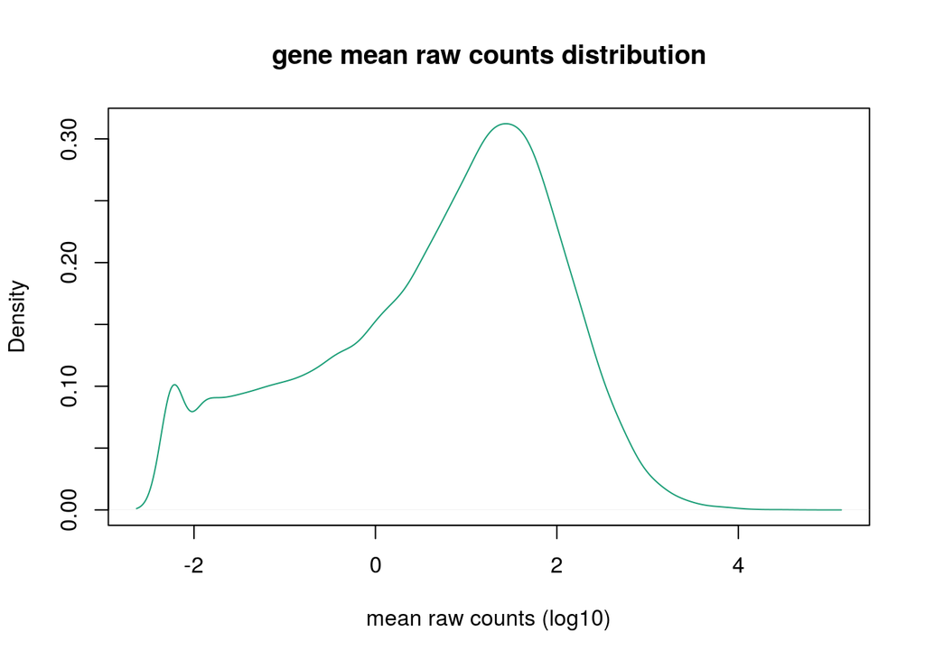

```r
plot(density(log10(rowMeans(kt))),col=pal[1],
     main="gene mean raw counts distribution",
     xlab="mean raw counts (log10)")
```

```r
#density=likelihood, chance
# plot the likelihood that the mean of genes has this mean of raw counts
# give an idea of the read depth, here the majority of gene maps ~30 reads (1.5 log10)
```

Display all samples raw counts distribution

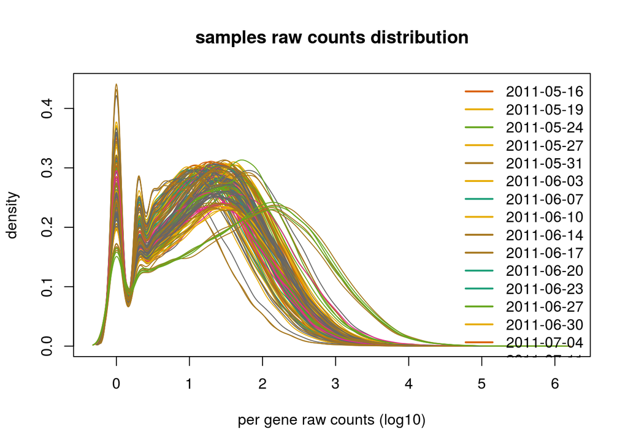

```r
cols <- sample(pal,nlevels(samples$Sampling_Date),replace = TRUE)
plot.multidensity(mclapply(1:ncol(kt),function(k){log10(kt)[,k]},mc.cores=16L),
                  col=cols[as.integer(samples$Sampling_Date)],
                  legend.x="topright",
                  legend=levels(samples$Sampling_Date),
                  legend.col=cols,
                  legend.lwd=2,
                  main="samples raw counts distribution",
                  xlab="per gene raw counts (log10)")
```

```r
# plot the likelihood that a gene in different time points has a certain number of counts
# genes have a lot of chances (0.2 to 0.4 depending on the dates) to have a count of one
# genes also have a lot of chances (0.2 to 0.3) to have between 2 and 100 counts
# genes have fewer chances (0.2 to 0.0) to have between 100 and a 1000 counts per gene
# genes have even fewer chances (0.05 to 0.0) to have very high counts (1000 to 100000)= "powertail"
```

The later samples (winter) have been sequence deeper than the older ones

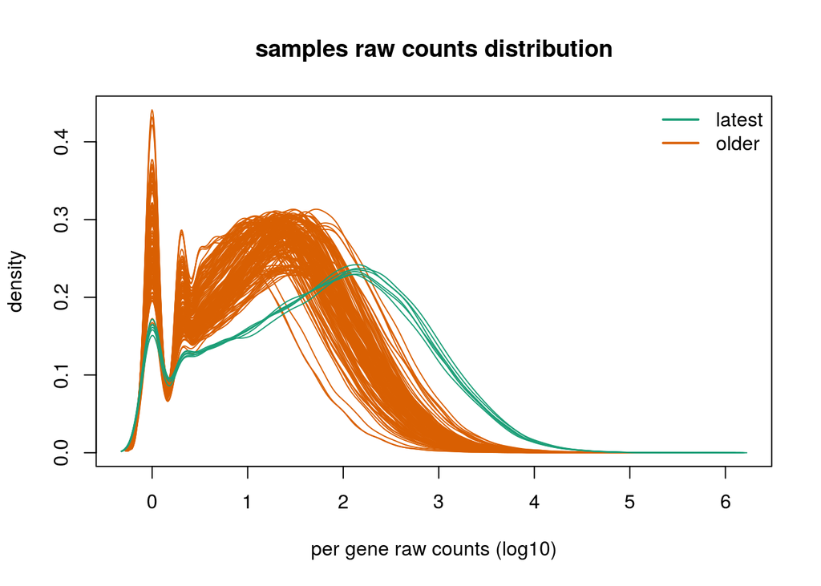

```r
dataset <- factor(ifelse(grepl("P7912",samples$Sequencing_ID),"latest","older"))
plot.multidensity(mclapply(1:ncol(kt),function(k){log10(kt)[,k]},mc.cores=16L),
                  col=pal[as.integer(dataset)],
                  legend.x="topright",
                  legend=levels(dataset),
                  legend.col=pal[1:2],
                  legend.lwd=2,
                  main="samples raw counts distribution",
                  xlab="per gene raw counts (log10)")
```

## 2.2 Raw data export

```r
dir.create(file.path("analysis","kallisto"),showWarnings=FALSE,recursive=TRUE)
write.csv(kt,file="analysis/kallisto/spruce-needles-unormalised-gene-expression_data.csv")
save(kt, samples, file = "analysis/kallisto/counts.rda")

#load("counts.rda")
```

#### 2.2.0.1 Merge technical replicates

Merge technical replicates

```r
kt_tech_merged <- do.call(cbind,lapply(split.data.frame(t(kt),samples$Sampling_ID),colSums))
# transpose the count table kt to get the samples' names as rows in order to process them next (functions process rows and not columns)
# then, do the sums of counts for all genes at one date
# finally, bind again the splitted rows to reunified a count table with technical replicates merged for each dates
```

Merge sampling dates for technical replicates

```r
sampling_dates_merged <- factor(sapply(split(as.character(samples$Sampling_Date),
                                             samples$Sampling_ID),unique))
```

Save count table with technical replicates merged

```r
save(sampling_dates_merged, kt_tech_merged, file="analysis/kallisto/kt_tech_merged.rda")
```

Plot

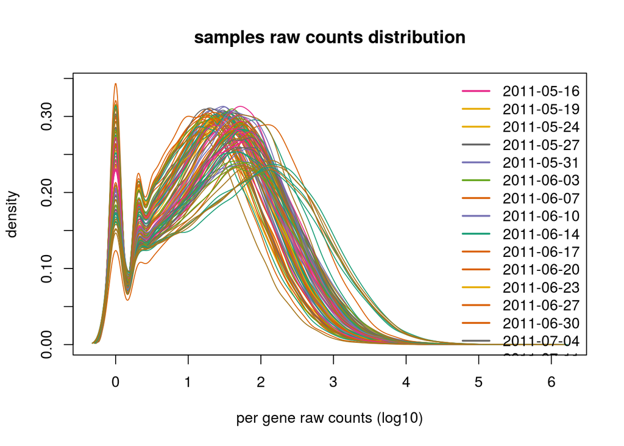

```r
cols <- sample(pal,nlevels(sampling_dates_merged),replace = TRUE)
plot.multidensity(mclapply(1:ncol(kt_tech_merged),
                           function(k){log10(kt_tech_merged)[,k]},mc.cores=16L),
                  col=cols[as.integer(sampling_dates_merged)],
                  legend.x="topright",
                  legend=levels(sampling_dates_merged),
                  legend.col=cols,
                  legend.lwd=2,
                  main="samples raw counts distribution",
                  xlab="per gene raw counts (log10)")
```

#### 2.2.0.2 Discard the NE samples which were resequenced with higher depth as TR00

(keep TR00 with the same number) find the bad samples

```r
samples_names <- colnames(kt_tech_merged)
samples_names
```

```
##   [1] "NE-001"  "NE-002"  "NE-003"  "NE-004"  "NE-005"  "NE-006"  "NE-007"
##   [8] "NE-008"  "NE-009"  "NE-010"  "NE-011"  "NE-012"  "NE-013"  "NE-014"
##  [15] "NE-015"  "NE-016"  "NE-017"  "NE-018"  "NE-019"  "NE-020"  "NE-021"
##  [22] "NE-022"  "NE-023"  "NE-024"  "NE-025"  "NE-026"  "NE-027"  "NE-028"
##  [29] "NE-029"  "NE-030"  "NE-031"  "NE-032"  "NE-033"  "NE-034"  "NE-035"
##  [36] "NE-036"  "NE-037"  "NE-039"  "NE-040"  "NE-044"  "NE-045"  "NE-046"
##  [43] "NE-047"  "NE-049"  "NE-050"  "NE-052"  "NE-053"  "NE-057"  "NE-058"
##  [50] "NE-059"  "NE-060"  "NE-062"  "NE-063"  "NE-064"  "NE-065"  "NE-066"
##  [57] "NE-067"  "NE-068"  "NE-069"  "NE-070"  "NE-071"  "TR00034" "TR00035"
##  [64] "TR00038" "TR00041" "TR00047" "TR00048" "TR00049" "TR00050" "TR00051"
##  [71] "TR00053" "TR00055" "TR00057" "TR00061" "TR00062" "TR00063" "TR00064"
##  [78] "TR00065" "TR00066" "TR00067" "TR00068" "TR00069" "TR00070" "TR00072"
##  [85] "TR00073" "TR00074" "TR00075" "TR00076" "TR00077" "TR00078" "TR00079"
##  [92] "TR00080" "TR00081" "TR00082" "TR00084" "TR00085" "TR00086" "TR00088"
##  [99] "TR00089" "TR00091" "NE-101"  "NE-102"  "NE-103"  "NE-104"  "NE-105"
## [106] "NE-106"
```

```r
new_names <- sub("NE-|TR00","",samples_names)
new_names
```

```
##   [1] "001" "002" "003" "004" "005" "006" "007" "008" "009" "010" "011"
##  [12] "012" "013" "014" "015" "016" "017" "018" "019" "020" "021" "022"
##  [23] "023" "024" "025" "026" "027" "028" "029" "030" "031" "032" "033"
##  [34] "034" "035" "036" "037" "039" "040" "044" "045" "046" "047" "049"
##  [45] "050" "052" "053" "057" "058" "059" "060" "062" "063" "064" "065"
##  [56] "066" "067" "068" "069" "070" "071" "034" "035" "038" "041" "047"
##  [67] "048" "049" "050" "051" "053" "055" "057" "061" "062" "063" "064"
##  [78] "065" "066" "067" "068" "069" "070" "072" "073" "074" "075" "076"
##  [89] "077" "078" "079" "080" "081" "082" "084" "085" "086" "088" "089"
## [100] "091" "101" "102" "103" "104" "105" "106"
```

```r
list <- split(samples_names, new_names)
list
```

```
## $`001`
## [1] "NE-001"
##
## $`002`
## [1] "NE-002"
##
## $`003`
## [1] "NE-003"
##
## $`004`
## [1] "NE-004"
##
## $`005`
## [1] "NE-005"
##
## $`006`
## [1] "NE-006"
##
## $`007`
## [1] "NE-007"
##
## $`008`
## [1] "NE-008"
##
## $`009`
## [1] "NE-009"
##
## $`010`
## [1] "NE-010"
##
## $`011`
## [1] "NE-011"
##
## $`012`
## [1] "NE-012"
##
## $`013`
## [1] "NE-013"
##
## $`014`
```

[output cut: 214 more lines]

```
##
## $`102`
## [1] "NE-102"
##
## $`103`
## [1] "NE-103"
##
## $`104`
## [1] "NE-104"
##
## $`105`
## [1] "NE-105"
##
## $`106`
## [1] "NE-106"
```

```r
duplicates <- list[sapply(list,length)==2]
bad_samples <- sapply(X = 1:length(duplicates),function(i){duplicates[[i]][1]})
```

remove from kt_tech_merged

```r
kt_tech_merged_cropped <- kt_tech_merged[,!colnames(kt_tech_merged) %in% bad_samples]
```

and remove the dates for this samples in the dates vector

```r
sampling_dates_merged_cropped <- sampling_dates_merged[!names(sampling_dates_merged) %in% bad_samples]

# #' Save cropped dates and counts
# Save(kt_tech_merged_cropped, sampling_dates_merged_cropped, file="kt_tech_merged_cropped.rda")
```

order dates chronologically

```r
dates <- sampling_dates_merged_cropped
ordered_dates <- dates[order(as.Date(dates, format="%Y-%m-%d"))]
```

order count table chronologically

```r
kt_tech_merged_cropped_ordered <- kt_tech_merged_cropped[,names(ordered_dates)]
```

Save ordered dates and counts

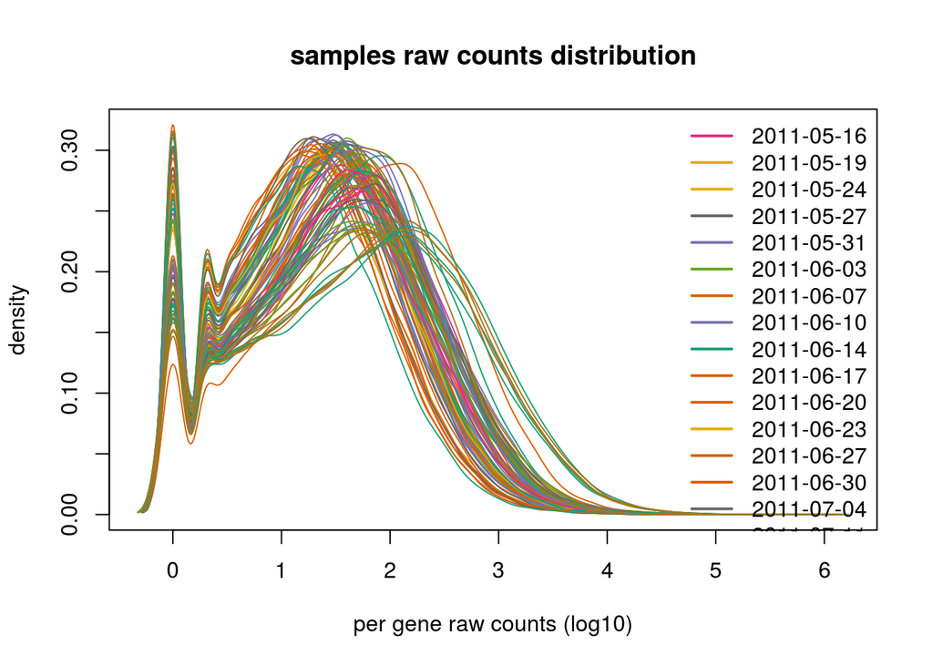

```r
save(ordered_dates, kt_tech_merged_cropped_ordered, file = "kt_tech_merged_cropped_ordered.rda")

plot.multidensity(mclapply(1:ncol(kt_tech_merged_cropped_ordered),
                           function(k){log10(kt_tech_merged_cropped_ordered)[,k]},mc.cores=16L),
                  col=cols[as.integer(ordered_dates)],
                  legend.x="topright",
                  legend=levels(ordered_dates),
                  legend.col=cols,
                  legend.lwd=2,
                  main="samples raw counts distribution",
                  xlab="per gene raw counts (log10)")
```

##### 2.2.0.2.1 Data normalisation

### 2.2.1 vst blind

```r
#load technical replicates merged data cropped for NE bad samples
load("kt_tech_merged_cropped_ordered.rda")
```

For visualization, the data is submitted to a variance stabilization transformation using DESeq2. The dispersion is estimated independently of the sample tissue and replicate

```r
dds.kt <- DESeqDataSetFromMatrix(
  countData = kt_tech_merged_cropped_ordered,
  colData = data.frame(date=ordered_dates),
  design = ~ date)
```

Check the size factors (i.e. the sequencing library size effect)

```r
dds.kt <- estimateSizeFactors(dds.kt)
sizes.kt <- sizeFactors(dds.kt)
# names(sizes.kt) <- colnames(kt)
# not useful sizes.kt already have the right names
pander(sizes.kt)
```

Table continues below

| NE-001 | NE-002 | NE-003 | NE-004 | NE-005 | NE-006 | NE-007 | NE-008 | NE-009 |
| --- | --- | --- | --- | --- | --- | --- | --- | --- |
| 0.7788 | 0.852 | 0.9409 | 0.9572 | 0.9195 | 0.91 | 0.8409 | 0.7515 | 0.66 |

Table continues below

| NE-010 | NE-011 | NE-012 | NE-013 | NE-014 | NE-015 | NE-016 | NE-017 | NE-018 |
| --- | --- | --- | --- | --- | --- | --- | --- | --- |
| 0.845 | 0.7188 | 0.8987 | 0.7925 | 0.6707 | 0.6273 | 0.7646 | 0.937 | 0.6844 |

Table continues below

| NE-019 | NE-020 | NE-021 | NE-022 | NE-023 | NE-024 | NE-025 | NE-026 | NE-027 |
| --- | --- | --- | --- | --- | --- | --- | --- | --- |
| 0.8008 | 0.8222 | 0.7236 | 0.6871 | 0.7253 | 0.6205 | 0.8709 | 0.7907 | 0.9511 |

Table continues below

| NE-028 | NE-029 | NE-030 | NE-031 | NE-032 | NE-033 | TR00034 | NE-036 |
| --- | --- | --- | --- | --- | --- | --- | --- |
| 0.7758 | 0.7664 | 0.465 | 0.5074 | 0.4748 | 0.4281 | 1.035 | 0.7566 |

Table continues below

| NE-037 | TR00035 | NE-039 | NE-040 | TR00038 | TR00041 | NE-044 | NE-045 |
| --- | --- | --- | --- | --- | --- | --- | --- |
| 0.5084 | 1.195 | 0.4905 | 0.4236 | 1.005 | 1.216 | 1.137 | 0.6138 |

Table continues below

| NE-046 | TR00047 | TR00048 | TR00049 | NE-052 | TR00050 | TR00051 | TR00053 |
| --- | --- | --- | --- | --- | --- | --- | --- |
| 0.4915 | 1.242 | 1.262 | 1.281 | 0.8292 | 1.089 | 1.427 | 2.514 |

Table continues below

| TR00055 | NE-058 | TR00057 | NE-059 | NE-060 | TR00061 | TR00062 | TR00063 |
| --- | --- | --- | --- | --- | --- | --- | --- |
| 1.133 | 0.5815 | 1.311 | 0.3839 | 1.909 | 1.388 | 0.9735 | 1.513 |

Table continues below

| TR00064 | TR00065 | TR00066 | TR00067 | TR00068 | TR00069 | TR00070 | NE-071 |
| --- | --- | --- | --- | --- | --- | --- | --- |
| 1.065 | 1.327 | 1.026 | 1.481 | 1.055 | 1.345 | 0.9363 | 1.568 |

Table continues below

| TR00072 | TR00073 | TR00074 | TR00075 | TR00076 | TR00077 | TR00078 | TR00079 |
| --- | --- | --- | --- | --- | --- | --- | --- |
| 1.062 | 0.9231 | 1.451 | 1.31 | 1.133 | 1.258 | 1.028 | 1.422 |

Table continues below

| TR00080 | TR00081 | TR00082 | TR00084 | TR00085 | TR00086 | TR00088 | TR00089 |
| --- | --- | --- | --- | --- | --- | --- | --- |
| 1.506 | 1.415 | 1.297 | 1.305 | 1.154 | 1.286 | 1.37 | 1.577 |

| TR00091 | NE-101 | NE-102 | NE-103 | NE-104 | NE-105 | NE-106 |
| --- | --- | --- | --- | --- | --- | --- |
| 1.177 | 4.01 | 3.267 | 2.881 | 3.258 | 3.444 | 3.675 |

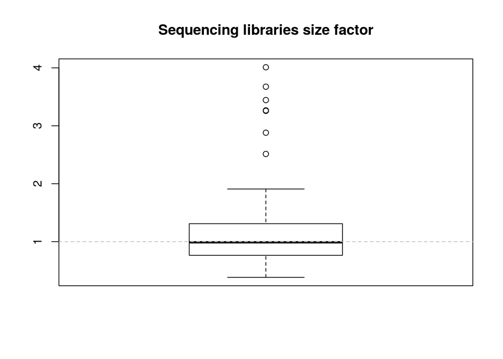

```r
boxplot(sizes.kt, main="Sequencing libraries size factor")
abline(h=1,lty=2,col="gray")
```